# Actividad-extracurricular-04b-python formatters-PJF

### ESCUELA POLITÉCNICA NACIONAL

### FACULTAD DE INGENIERÍA EN SISTEMAS

### METODOS NUMERICOS ICCD412

*JUAN FRANCISCO PINTO ANDRANGO*

*Actividad Extracurricular 04B Python Formatters*

*GR1CC*

*FECHA DE ENTREGA 28 DE ENERO DEL 2026*

#### Python Formatters

los python formatters son herramientas que reescriben de manera automatica el codigo funte para que este cumpla un estilo especifico y estandarizado esto no afecta la logica del programa o su funcionamiento.

los formatters en python se refieren a los metodos para dar formato a ciertas cadenas de texto que permiten insertar valores de manera dinamica con un control de alineación, precisíon y tipos, tambien herramientas externas como black o ruff que formatean el estilo del código para mantener la consitencia facilitando la lectura y el mantenimiento del codigo.

## black formatters

black es el formatter más famoso y utilizado en el mundo de python, es un estandar en la industria por su filosofia

" Deja de pensar en el formato y concentrate en el codigo "

###### codigo sin black formatters

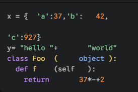

##### codigo con black formatters

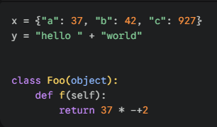

### Autopep8 formatters

Autopep8 es un gigantesco formateador de python. ya que automatiza el cumplimiento de la guia PEP 8, autopep8 es mas un corrector de errores busca infraciones de la norma PEP 8 y las arregla intentanto modificar el resto del codigo lo menos posible.

##### codigo sin Autopep8

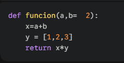

#### codigo con Autopep8

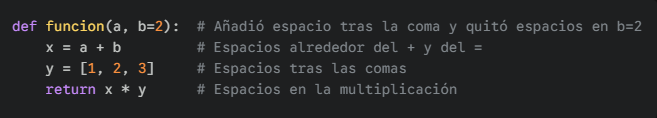

### Ruff formatters

ruff formatters es un formtatters mas velos que black cuando se usa Ruff se obtiene el estilo de black pero es hasta 100 veces mas rapido. se lo usa en grandes empresas como Microsoft, Google y Netflix esto gracias a su eficiencia

##### codigo sin Ruff

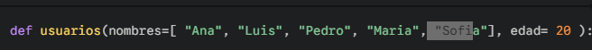

##### codigo con Ruff

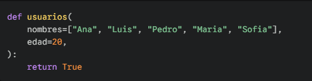

### YAPF Formatters

YAPF es un formateador desarrollado y usado ampliamente en Google. YAPF calculo de mejor manera el formateo de un bloque de codigo, su funcion es que el codigo se vea bien y que ademoas cumpla las reglas. Es muy configurable para tener el control total

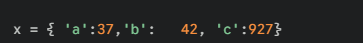

### link del repositorio de Git-Hub

https://github.com/JuanfranPinto/Metodos-Numericos-/blob/main/Actividad-extracurricular-04b-python%20formatters-PJF.ipynb